# MA50258: Applied Statistics Lab 1

# Instructions

- As indicated in each part, complete your answers, in the ‘Lab1.Rmd’ file which can be downloaded by clicking in the **Code button** at the top right of this page. If the **Code button** does not work you can download the ‘Lab1.Rmd’ file from the Moodle page. You should open this file in RStudio.
- I’m going to ask that you trust me with this lab! You haven’t learned about this kind of document yet, called an R Markdown (.Rmd) file- please just go with it! I promise we’ll actually explain it later.
- After you complete your answers you should convert this file into an HTML file by following the instructions in the Knit to html section at the end of this file!
- You should submit both your completed R Markdown file (which should be named ‘Lab1.Rmd’) and the created HTML file (which should be named ‘Lab1.html’) to the [submission point in Moodle](https://moodle.bath.ac.uk/mod/assign/view.php?id=1111421)
- This is lab is a **formative assessment** and you will receive feedback to your submitted work on an informal basis.

# Introduction

The goal of this lab is to consolidate your knowledge about `R`’s tools for data handling and exploration (`dplyr` package), and data visualisation (`ggplot2` package). You are encouraged to use pipes (`%>%`) as well as appropriate indentation in your code answers.

# Packages

Below is the list of packages that we will use in this lab. Remember to install them with the command:

```r
install.packages("name_of_package")
```

before using them! Do not install packages within your scripts! You should install a package once per computer. You can see the full list of packages installed on your computer by looking at the *Packages* tab in the bottom right pane in RStudio.

```r
library(tidyverse)
library(lubridate) # to manipulate  variables in date format
# lubridate is included in tidyverse but not loaded by default
library(janitor) # to clean names in a data frame
library(GGally) # to draw scatter plot matrices using ggplot2
## GGally is an add-on package to ggplot2
library(knitr) # general purpose literate programming tools
library(klippy) # to copy chunks of code to clipboard
# klippy should be installed using
# remotes::install_github("rlesur/klippy")
```

# Part I: Weather data

In this part you will work with the same four weather datasets used last semester in Lab 1 of CM50266. The data contains daily values of:

- outdoor temperature,
- indoor temperature and humidity,
- barometric pressure and
- rainfall

from October 2016 to October 2017.

## Load the data

The four csv files can be downloaded as a zip file here. Save the files and place them in your working directory.

### Task 1

In the code chunk below, write `R` code to load the four datasets into `R` data frames using the function `read_csv` from the [readr package](https://readr.tidyverse.org/reference/index.html) (this package is loaded when loading the `tidyverse` package). The data frames names in `R` should be: ``pressure`, `indoor_temp`, `outdoor_temp` and `rainfall`

```r
# your code here
pressure <- read_csv("barometer-last-year.csv")
indoor_temp <- read_csv("indoor-temperature-last-year.csv")
outdoor_temp <- read_csv("outside-temperature-last-year.csv")
rainfall <- read_csv("rainfall-last-year.csv")
```

## Variable names and classes

Some of the variables in the data frames created above have messy names that contain spaces and uppercase letters. To convert the variable names to [snake_case](https://en.wikipedia.org/wiki/Snake_case) we can use the function `clean_names` from the `janitor` package.

### Task 2

In the code chunk below, write `R` code to change all the variable names in the four data frames to snake_case. The name of the data frames should stay the same. Also, display the variable names (before and after applying `clean_names`) of all four data frames using the `R` function `names`.

```r
# your code here
# Before
cat("Before applying clean_names():\n")
```

```
## Before applying clean_names():
```

```r
cat("pressure is: ", names(pressure), "\n")
```

```
## pressure is:  DateTime Baro
```

```r
cat("indoor_temp is: ", names(indoor_temp), "\n")
```

```
## indoor_temp is:  DateTime Humidity Temperature Temperature_range (low) Temperature_range (high)
```

```r
cat("outdoor_temp is: ", names(outdoor_temp), "\n")
```

```
## outdoor_temp is:  DateTime Temperature Temperature_range (low) Temperature_range (high)
```

```r
cat("rainfall is: ", names(rainfall), "\n")
```

```
## rainfall is:  DateTime mm
```

```r
# Applying clean_names()
pressure <- pressure %>% clean_names()
indoor_temp <- indoor_temp %>% clean_names()
outdoor_temp <- outdoor_temp %>% clean_names()
rainfall <- rainfall %>% clean_names()

# After
cat("After applying clean_names():\n")
```

```
## After applying clean_names():
```

```r
cat("pressure is: ", names(pressure), "\n")
```

```
## pressure is:  date_time baro
```

```r
cat("indoor_temp is: ", names(indoor_temp), "\n")
```

```
## indoor_temp is:  date_time humidity temperature temperature_range_low temperature_range_high
```

```r
cat("outdoor_temp is: ", names(outdoor_temp), "\n")
```

```
## outdoor_temp is:  date_time temperature temperature_range_low temperature_range_high
```

```r
cat("rainfall is: ", names(rainfall), "\n")
```

```
## rainfall is:  date_time mm
```

### Task 3

In the code chunk below, write `R` code to display the classes of all variables in the four data sets. How many different types of variables there are? You may want to read the Details in the help file `?DateTimeClasses`.

```r
# Your code here
# you may use any of the following commands:
# class
# str
# glimpse
# Displaying the classes of all variables in the four data sets
# code for "pressure" dataframe
cat("pressure has", ncol(pressure), "variables.", "\n")
```

```
## pressure has 2 variables.
```

```r
for (col_name in names(pressure)) {
  cat("Class of", col_name, ":", class(pressure[[col_name]]), "\n")
}
```

```
## Class of date_time : POSIXct POSIXt
## Class of baro : numeric
```

```r
# code for "indoor_temp" dataframe
cat("indoor_temp has", ncol(indoor_temp), "variables.", "\n")
```

```
## indoor_temp has 5 variables.
```

```r
for (col_name in names(indoor_temp)) {
  cat("Class of", col_name, ":", class(indoor_temp[[col_name]]), "\n")
}
```

```
## Class of date_time : POSIXct POSIXt
## Class of humidity : numeric
## Class of temperature : numeric
## Class of temperature_range_low : numeric
## Class of temperature_range_high : numeric
```

```r
# code for "outdoor_temp" dataframe
cat("outdoor_temp has", ncol(outdoor_temp), "variables.", "\n")
```

```
## outdoor_temp has 4 variables.
```

```r
for (col_name in names(outdoor_temp)) {
  cat("Class of", col_name, ":", class(outdoor_temp[[col_name]]), "\n")
}
```

```
## Class of date_time : POSIXct POSIXt
## Class of temperature : numeric
## Class of temperature_range_low : numeric
## Class of temperature_range_high : numeric
```

```r
# code for "rainfall" dataframe
cat("rainfall has", ncol(rainfall), "variables.", "\n")
```

```
## rainfall has 2 variables.
```

```r
for (col_name in names(rainfall)) {
  cat("Class of", col_name, ":", class(rainfall[[col_name]]), "\n")
}
```

```
## Class of date_time : POSIXct POSIXt
## Class of mm : numeric
```

## Join the data frames

We would like to combine the four data frames into one, based on the dates column. We can do this using the `left_join` function from the `dplyr` package. For example, to join the data frames `pressure` and `indoor_temp` we can use:

```r
?left_join
joined_data_frame <- pressure %>%
                        left_join(indoor_temp, by = "date_time")
```

### Task 4

In the code chunk below, write `R` code to join all four data sets to create a single data frame called `weather`. Pay special attention to the argument `suffix =` of `left_join`. You should use `c(".indoor",".outdoor")` as suffix.

```r
# Your code here
weather <- pressure %>%
  left_join(indoor_temp, by = "date_time", suffix = c(".pressure", ".indoor")) %>%
  left_join(outdoor_temp, by = "date_time", suffix = c(".indoor", ".outdoor")) %>%
  left_join(rainfall, by = "date_time", suffix = c(".outdoor", ".rainfall"))
glimpse(weather)
```

```
## Rows: 355
## Columns: 10
## $ date_time                      <dttm> 2016-10-09, 2016-10-10, 2016-10-11, 20…
## $ baro                           <dbl> 1021.9, 1019.9, 1015.8, 1013.2, 1005.9,…
## $ humidity                       <dbl> 54, 52, 51, 51, 52, 52, 53, 53, 53, 54,…
## $ temperature.indoor             <dbl> 21.93, 21.77, 21.36, 21.44, 21.22, 21.0…
## $ temperature_range_low.indoor   <dbl> 21.0, 20.4, 19.9, 20.0, 20.1, 19.6, 20.…
## $ temperature_range_high.indoor  <dbl> 22.8, 23.6, 23.0, 23.6, 22.3, 22.6, 22.…
## $ temperature.outdoor            <dbl> 10.66, 8.94, 8.69, 11.55, 9.40, 9.85, 1…
## $ temperature_range_low.outdoor  <dbl> 7.2, 5.6, 5.3, 9.0, 6.0, 6.8, 8.2, 7.8,…
## $ temperature_range_high.outdoor <dbl> 13.8, 12.8, 14.3, 14.9, 13.3, 13.3, 14.…
## $ mm                             <dbl> 0.0, 0.0, 0.0, 0.0, 0.0, 1.1, 2.1, 8.4,…
```

## Statistical summaries

We already learned that we can obtain summaries of the data in `R` using the `summary` function:

```r
summary(weather)
```

```
##    date_time                           baro           humidity
##  Min.   :2016-10-09 00:00:00.00   Min.   : 979.6   Min.   :37.00
##  1st Qu.:2017-01-06 12:00:00.00   1st Qu.:1004.9   1st Qu.:44.00
##  Median :2017-04-06 00:00:00.00   Median :1010.5   Median :48.00
##  Mean   :2017-04-06 19:56:37.18   Mean   :1010.0   Mean   :48.52
##  3rd Qu.:2017-07-03 12:00:00.00   3rd Qu.:1016.0   3rd Qu.:52.00
##  Max.   :2017-10-09 00:00:00.00   Max.   :1035.6   Max.   :59.00
##                                                    NA's   :1
##  temperature.indoor temperature_range_low.indoor temperature_range_high.indoor
##  Min.   :18.04      Min.   :14.90                Min.   :19.70
##  1st Qu.:20.34      1st Qu.:18.73                1st Qu.:22.50
##  Median :21.71      Median :20.60                Median :23.20
##  Mean   :21.83      Mean   :20.56                Mean   :23.53
##  3rd Qu.:22.71      3rd Qu.:21.90                3rd Qu.:24.10
##  Max.   :29.21      Max.   :28.20                Max.   :31.10
##  NA's   :1          NA's   :1                    NA's   :1
##  temperature.outdoor temperature_range_low.outdoor
##  Min.   :-1.81       Min.   :-4.100
##  1st Qu.: 7.39       1st Qu.: 4.350
##  Median :10.96       Median : 8.000
##  Mean   :11.14       Mean   : 7.866
##  3rd Qu.:15.05       3rd Qu.:12.050
##  Max.   :26.38       Max.   :18.700
##
##  temperature_range_high.outdoor       mm
##  Min.   : 1.50                  Min.   : 0.000
##  1st Qu.:10.25                  1st Qu.: 0.000
##  Median :15.10                  Median : 0.000
##  Mean   :15.52                  Mean   : 1.549
##  3rd Qu.:19.85                  3rd Qu.: 1.100
##  Max.   :38.50                  Max.   :23.200
##                                 NA's   :2
```

There are separate functions for each component of this output. See for example `?mean` `?min` `?max` etc. Note that these have specific optional arguments for missing data.

```r
mean(weather$mm)
```

```
## [1] NA
```

```r
mean(weather$mm, na.rm = TRUE)
```

```
## [1] 1.548725
```

The sample standard deviation is not included in `summary()`. We can use the `R` function `apply` to evaluate any function on either the rows or columns of our data.

```r
?apply
?sd # help on the standrad deviation
apply(weather, 2, sd, na.rm = T)
```

```
## Warning in var(if (is.vector(x) || is.factor(x)) x else as.double(x), na.rm =
## na.rm): NAs introduced by coercion
```

```
##                      date_time                           baro
##                             NA                       9.869662
##                       humidity             temperature.indoor
##                       5.188886                       2.058307
##   temperature_range_low.indoor  temperature_range_high.indoor
##                       2.405125                       1.701466
##            temperature.outdoor  temperature_range_low.outdoor
##                       5.355042                       4.878930
## temperature_range_high.outdoor                             mm
##                       7.034445                       3.324599
```

We get a warning message since the first column (a date) corresponds to a type of variable where the standard deviation is not necessarily well defined. We can get around this by re-doing the command, taking out the first column:

```r
apply(weather[,-1], 2, sd, na.rm = T)
```

```
##                           baro                       humidity
##                       9.869662                       5.188886
##             temperature.indoor   temperature_range_low.indoor
##                       2.058307                       2.405125
##  temperature_range_high.indoor            temperature.outdoor
##                       1.701466                       5.355042
##  temperature_range_low.outdoor temperature_range_high.outdoor
##                       4.878930                       7.034445
##                             mm
##                       3.324599
```

You may want to read this chapter on [subsetting atomic vectors](https://adv-r.hadley.nz/subsetting.html) in R.

### Task 5

In the code chunk below, write `R` code to compute the minimum, maximum, mean and standard deviation for each weather measurement. You should the place the results into a data frame which in turn should be converted to a table using the `kable`command from the `knitr` package.

```r
# Your code here
# Define the variables for which summary statistics are needed
# Apply the function to each column of the dataframe
weather_summary <- apply(weather[,-1], 2, function(x) c(min = min(x, na.rm = TRUE),
                                                        max = max(x, na.rm = TRUE),
                                                        mean = mean(x, na.rm = TRUE),
                                                        sd = sd(x, na.rm = TRUE)))
kable(weather_summary)
```

|  | baro | humidity | temperature.indoor | temperature_range_low.indoor | temperature_range_high.indoor | temperature.outdoor | temperature_range_low.outdoor | temperature_range_high.outdoor | mm |
| --- | --- | --- | --- | --- | --- | --- | --- | --- | --- |
| min | 979.600000 | 37.000000 | 18.040000 | 14.900000 | 19.700000 | -1.810000 | -4.100000 | 1.500000 | 0.000000 |
| max | 1035.600000 | 59.000000 | 29.210000 | 28.200000 | 31.100000 | 26.380000 | 18.700000 | 38.500000 | 23.200000 |
| mean | 1009.998873 | 48.519774 | 21.827885 | 20.555932 | 23.533616 | 11.138877 | 7.865634 | 15.524225 | 1.548725 |
| sd | 9.869662 | 5.188886 | 2.058307 | 2.405125 | 1.701466 | 5.355041 | 4.878930 | 7.034445 | 3.324599 |

## Pairwise relationships and correlations

The correlation coefficient is a measure of the *linear* relationship between two numeric variables. We can calculate this correlation coefficient for two variables using the `cor` function in `R`. For example, the correlation between the minimum and maximum outdoor temperatures can be computed as follows:

```r
?cor
cor(weather$temperature_range_low.outdoor,
    weather$temperature_range_high.outdoor)
```

```
## [1] 0.8394635
```

Unsurprisingly, these two variables are strongly positively correlated!

To compute the correlation matrix corresponding to a data frame we can use `cor` again but with a single argument which should be a data frame where all variables are of numeric class. For example:

```r
cor(indoor_temp) # will give an error
```

```
## Error in cor(indoor_temp): 'x' must be numeric
```

```r
cor(indoor_temp[,-1]) # removes the date column
```

```
##                         humidity temperature temperature_range_low
## humidity               1.0000000   0.4812819             0.5702552
## temperature            0.4812819   1.0000000             0.9786879
## temperature_range_low  0.5702552   0.9786879             1.0000000
## temperature_range_high 0.2471381   0.9113965             0.8263378
##                        temperature_range_high
## humidity                            0.2471381
## temperature                         0.9113965
## temperature_range_low               0.8263378
## temperature_range_high              1.0000000
```

### Task 6

In the code chunk below, write `R` code to find and display the correlation between all pairs of the weather measurements. Remove all rows in the data that contain missing values before computing the correlations (you may use `na.omit` or `complete.cases` for this). You should convert the correlation matrix to a table using the `kable` command from the `knitr` package.

```r
# Your code here
# Pay special attention to the argument 'suffix' of 'left_join'
# You use the argument `use = 'pairwise.complete.obs'` in `cor`
weather_correlation <- cor(weather[, -1], use = "pairwise.complete.obs")
kable(weather_correlation)
```

|  | baro | humidity | temperature.indoor | temperature_range_low.indoor | temperature_range_high.indoor | temperature.outdoor | temperature_range_low.outdoor | temperature_range_high.outdoor | mm |
| --- | --- | --- | --- | --- | --- | --- | --- | --- | --- |
| baro | 1.0000000 | -0.2007855 | -0.1015171 | -0.1444285 | -0.0368025 | -0.1575705 | -0.1994764 | -0.0874524 | -0.4793487 |
| humidity | -0.2007855 | 1.0000000 | 0.4812819 | 0.5702552 | 0.2471381 | 0.6447195 | 0.6904913 | 0.5407054 | 0.1708414 |
| temperature.indoor | -0.1015171 | 0.4812819 | 1.0000000 | 0.9786879 | 0.9113965 | 0.9024417 | 0.8348624 | 0.8972451 | -0.0150833 |
| temperature_range_low.indoor | -0.1444285 | 0.5702552 | 0.9786879 | 1.0000000 | 0.8263378 | 0.9371275 | 0.8945247 | 0.8993505 | 0.0379748 |
| temperature_range_high.indoor | -0.0368025 | 0.2471381 | 0.9113965 | 0.8263378 | 1.0000000 | 0.7342645 | 0.6370493 | 0.7797886 | -0.1105265 |
| temperature.outdoor | -0.1575705 | 0.6447195 | 0.9024417 | 0.9371275 | 0.7342645 | 1.0000000 | 0.9543625 | 0.9520358 | 0.0241749 |
| temperature_range_low.outdoor | -0.1994764 | 0.6904913 | 0.8348624 | 0.8945247 | 0.6370493 | 0.9543625 | 1.0000000 | 0.8394635 | 0.0772097 |
| temperature_range_high.outdoor | -0.0874524 | 0.5407054 | 0.8972451 | 0.8993505 | 0.7797886 | 0.9520358 | 0.8394635 | 1.0000000 | -0.0624595 |
| mm | -0.4793487 | 0.1708414 | -0.0150833 | 0.0379748 | -0.1105265 | 0.0241749 | 0.0772097 | -0.0624595 | 1.0000000 |

## Plots

We can use `ggplot2` to draw (for example) the time series of average outdoor temperatures:

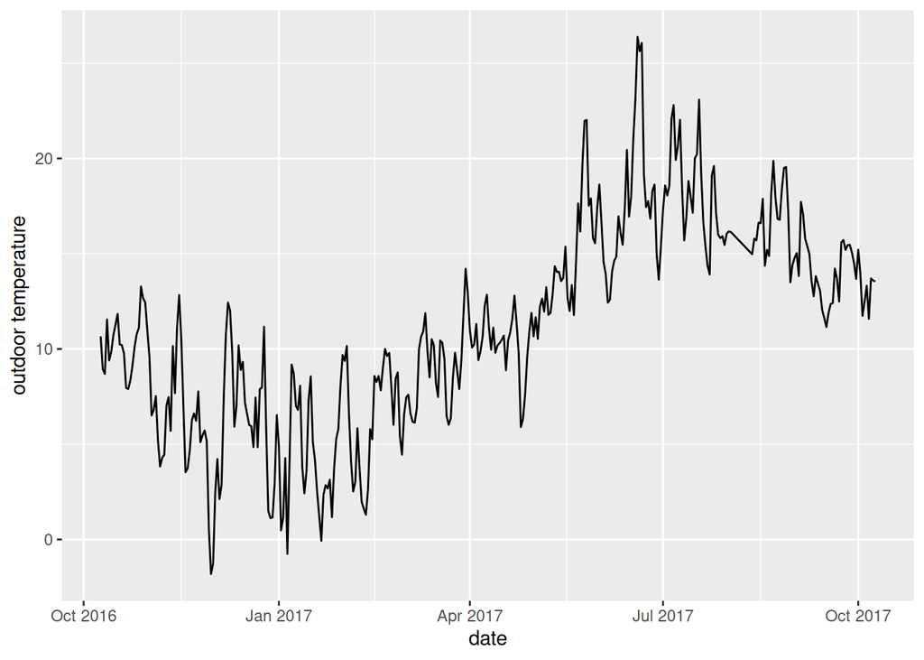

```r
?geom_line
weather %>%
  ggplot() +
    geom_line(aes(date_time,
                  temperature.outdoor)) +
    labs(x = "date", y = "outdoor temperature")
```

or a scatter plot of the minimum versus maximum outdoor temperatures:

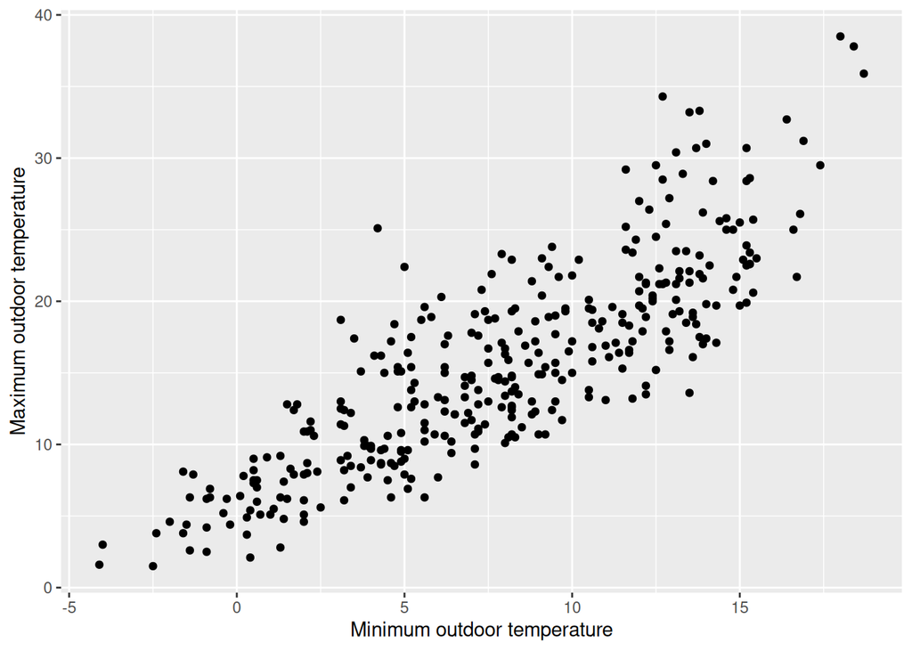

```r
weather %>% ggplot() +
  geom_point(aes(temperature_range_low.outdoor,
                 temperature_range_high.outdoor)) +
  labs(x = "Minimum outdoor temperature",
       y = "Maximum outdoor temperature")
```

The R function `pairs` in`R` will create a scatter plot matrix of all possible pairs of numeric variables in a data frame.

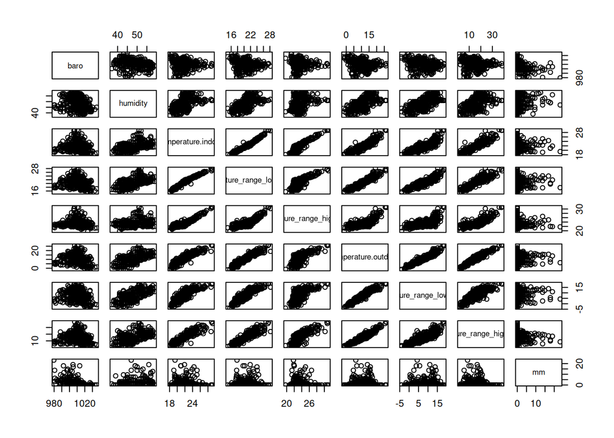

```r
pairs(weather[,-1])
```

For a large data frame, this is not exactly visually appealing, but it can work for smaller ones:

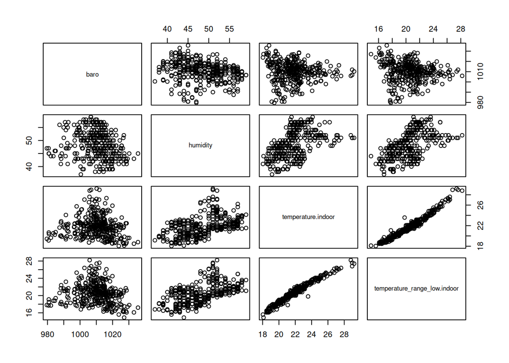

```r
pairs(weather[,2:5])
```

There is no single command to draw a scatter plot matrix in `ggplot2` but we can use the ``GGally` package and its function `ggpairs` to do it with a single command.

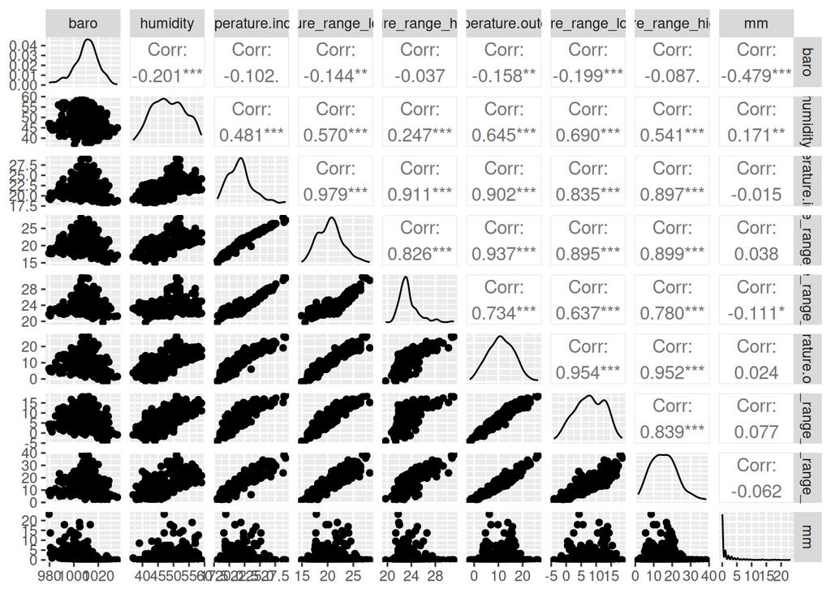

```r
ggpairs(weather[,-1])
```

which looks visually more appealing!

In `ggplot2` is easy to stratify plots by a factor variable. Let’s try looking at the relationship between minimum and maximum outdoor temperature but now by broken by month:

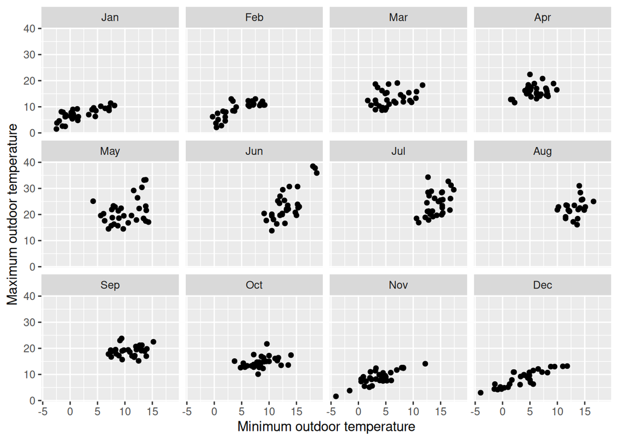

```r
?month # from  `lubridate` package
# to create the month variable on the fly!
weather %>%
  ggplot(aes(temperature_range_low.outdoor,
             temperature_range_high.outdoor)) +
  geom_point() +
  facet_wrap(~month(date_time, label = TRUE)) +
  labs(x = "Minimum outdoor temperature",
       y = "Maximum outdoor temperature")
```

### Task 7

In the code chunk below, write `R` code to plot the relationship between humidity and barometric pressure, both overall and also by month.

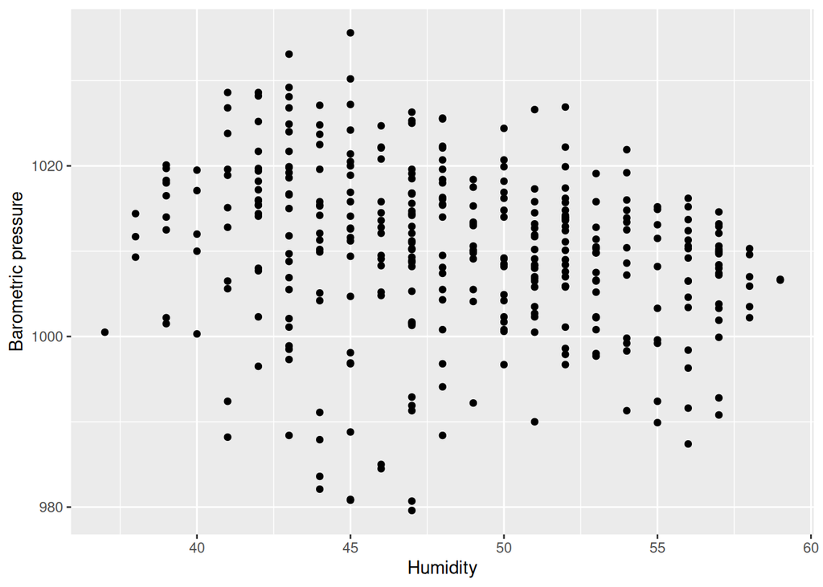

```r
# Your code here

# Plot by overall
weather %>%
  ggplot(aes(humidity, baro)) +
  geom_point() +
  labs(x = "Humidity", y = "Barometric pressure")
```

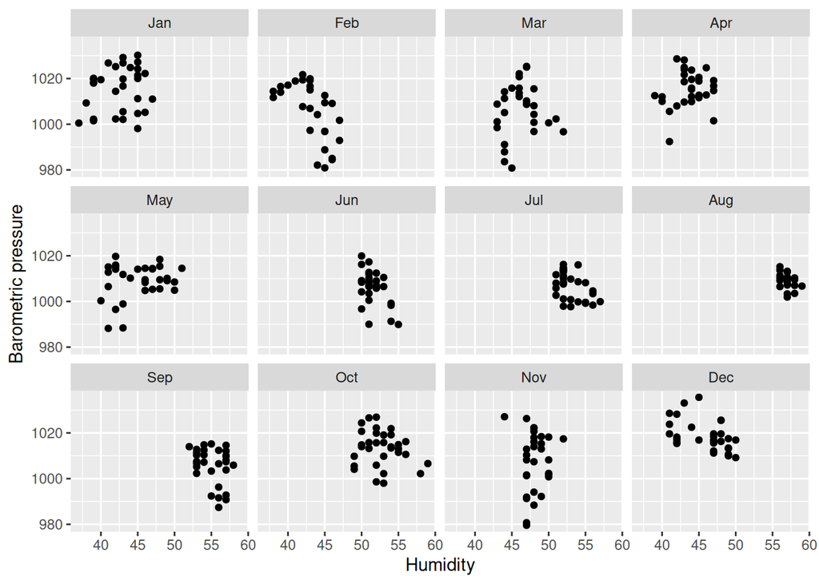

```r
# Plot by month
weather %>%
  ggplot(aes(humidity, baro)) +
  geom_point() +
  facet_wrap(~month(date_time, label = TRUE)) +
  labs(x = "Humidity", y = "Barometric pressure")
```

** My answer: How tightly or sparsely humidity and barometric pressure fluctuate varies depending the seasons **

Write here in words what can you say about the linearity of the relationship of the variables. You may find elucidating reading the following two articles: - [Same Stats, Different Graphs: Generating Datasets with Varied Appearance and Identical Statistics through Simulated Annealing](https://www.autodesk.com/research/publications/same-stats-different-graphs)

- [The Datasaurus data package](https://cran.r-project.org/web/packages/datasauRus/vignettes/Datasaurus.html)

** *Remove text enclosed by `***` after completing* **

### Task 8

In the code chunk below, write `R` code to plot the time series of all three: minimum, average and maximum outdoor temperatures all in the same graph and in different line colours using `ggplot2`.

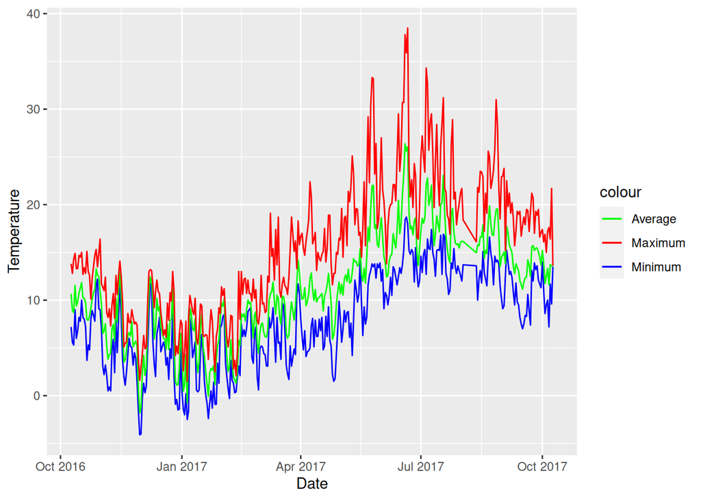

```r
# Your code here
weather %>%
  ggplot() +
  geom_line(aes(date_time, temperature_range_low.outdoor, colour = "Minimum")) +
  geom_line(aes(date_time, temperature.outdoor, colour = "Average")) +
  geom_line(aes(date_time, temperature_range_high.outdoor, colour = "Maximum")) +
  labs(x = "Date", y = "Temperature") +
  scale_colour_manual(values = c("Minimum" = "blue", "Average" = "green", "Maximum" = "red"))
```

# Part II: Sustainable development goals (SDG) data

In this part we will use a different data set! The data comes from UNESCO’s [Sustainable Development Goals](https://en.unesco.org/sustainabledevelopmentgoals). The data is of free access via UNESCO [Institute of Statistics](http://data.uis.unesco.org). The dataset contains:

- Information about 89 countries
- 9 variables of education and socio-demographic
- Yearly information from 2013 to 2017

## Variable dictionary

The description of the variables in the SDG data set is below.

- `country`: Name of the country (character)
- `year`: year of observation
- `continent`: name of the continent (character)
- `region`: region of the continent (character)
- `years_education`: mean number of years in education for population over 25 years of age
- `gdp`: GDP per capita (in US dollars)
- `life_expectancy` = Life expectancy at birth in years
- `infant_mortality_rate`= infant mortality rate (per 1,000 live births)
- `income_class` = World Bank income classification (character): L =low, LM =low-middle, UM = middle-upper and H= upper

## Load the data

The data can be loaded into `R` using the following command:

```r
sdg <- read_csv("sdg.csv")
```

Have a quick glimpse of the data:

```r
glimpse(sdg)
```

```
## Rows: 268
## Columns: 9
## $ country               <chr> "Germany", "Germany", "Germany", "Germany", "Dom…
## $ year                  <dbl> 2013, 2014, 2015, 2016, 2013, 2014, 2015, 2016, …
## $ continent             <chr> "Europe", "Europe", "Europe", "Europe", "America…
## $ region                <chr> "Western Europe", "Western Europe", "Western Eur…
## $ years_education       <dbl> 13.97443, 14.10672, 14.15360, 14.20745, 7.63264,…
## $ gdp                   <dbl> 46285.764, 47959.993, 41139.545, 42098.920, 6238…
## $ life_expectancy       <dbl> 80.49024, 81.09024, 80.64146, 80.99024, 72.76300…
## $ infant_mortality_rate <dbl> 3.3, 3.3, 3.2, 3.2, 27.1, 26.6, 26.0, 25.4, 3.5,…
## $ income_class          <chr> "H", "H", "H", "H", "UM", "UM", "UM", "UM", "H",…
```

Similar to the `gapminder` dataset, each row in `sdg` refers to an specific country in a specific year.

## Missing values

The `R` function `is.na` takes a vector or data frame as argument and returns a vector or data frame of only logical values where `TRUE` means the corresponding entry corresponds to a `NA` (missing value) and `FALSE` otherwise. For example

```r
sum(is.na(sdg$life_expectancy))
```

```
## [1] 6
```

tells us that the variable `life_expectancy` has 6 missing values.

### Task 9

In the code chunk below, write `R` code to find and display the total number of missing values in the `sdg` data frame and also broken by each variable.

```r
# Your code here
total_missing <- sum(is.na(sdg))
cat("Total number of missing values:", total_missing, "\n")
```

```
## Total number of missing values: 11
```

```r
for (col_name in names(sdg)) {
  missing_values <- sum(is.na(sdg[[col_name]]))
  cat("Number of missing values in variable", col_name, ":", missing_values, "\n")
}
```

```
## Number of missing values in variable country : 0
## Number of missing values in variable year : 0
## Number of missing values in variable continent : 0
## Number of missing values in variable region : 0
## Number of missing values in variable years_education : 0
## Number of missing values in variable gdp : 0
## Number of missing values in variable life_expectancy : 6
## Number of missing values in variable infant_mortality_rate : 5
## Number of missing values in variable income_class : 0
```

## Descriptive Statistics

### Task 10

In the code chunk below, write `R` code to find and display:

- The 10 countries with the highest years in education in 2017!
- The 10 countries with lowest infant mortality in 2013!

You should the place the results into a data frame which in turn should be converted to a table using the `kable`command from the `knitr` package.

```r
# Your code here
highest_years_education <- sdg %>% filter(year == 2017) %>% slice_max(n = 10, years_education)
lowest_infant_mortality <- sdg %>% filter(year == 2013) %>% slice_min(n = 10, infant_mortality_rate)

kable(highest_years_education, caption = "10 countries with the highest years in education in 2017")
```

10 countries with the highest years in education in 2017

| country | year | continent | region | years_education | gdp | life_expectancy | infant_mortality_rate | income_class |
| --- | --- | --- | --- | --- | --- | --- | --- | --- |
| Estonia | 2017 | Europe | Northern Europe | 13.96194 | 20337.850 | 77.64146 | 2.2 | H |
| Lithuania | 2017 | Europe | Northern Europe | 13.30318 | 16840.939 | 74.67073 | 3.6 | H |
| Georgia | 2017 | Asia | Western Asia | 13.13296 | 4357.012 | 73.41400 | 8.9 | LM |
| Norway | 2017 | Europe | Northern Europe | 13.02868 | 75496.754 | 82.50976 | 2.1 | H |
| Puerto Rico | 2017 | Americas | Caribbean | 12.88085 | 31353.434 | 79.63454 | NA | H |
| Finland | 2017 | Europe | Northern Europe | 12.82413 | 46191.931 | 81.42927 | 1.5 | H |
| Slovenia | 2017 | Europe | Southern Europe | 12.77084 | 23442.704 | 81.17561 | 1.8 | H |
| Sweden | 2017 | Europe | Northern Europe | 12.54847 | 53744.429 | 82.30732 | 2.2 | H |
| Belgium | 2017 | Europe | Western Europe | 12.36665 | 44219.562 | 81.43902 | 3.0 | H |
| Australia | 2017 | Oceania | Australia and New Zealand | 12.36087 | 54066.471 | 82.49756 | 3.1 | H |

```r
kable(lowest_infant_mortality, caption = "10 countries with the lowest infant mortality in 2013")
```

| country | year | continent | region | years_education | gdp | life_expectancy | infant_mortality_rate | income_class |
| --- | --- | --- | --- | --- | --- | --- | --- | --- |
| Finland | 2013 | Europe | Northern Europe | 12.62611 | 49878.04 | 80.97561 | 2.1 | H |
| Slovenia | 2013 | Europe | Southern Europe | 12.46312 | 23496.60 | 80.32195 | 2.2 | H |
| Luxembourg | 2013 | Europe | Western Europe | 14.21147 | 113625.13 | 81.80000 | 2.2 | H |
| Singapore | 2013 | Asia | South-Eastern Asia | 11.20850 | 56967.43 | 82.24634 | 2.2 | H |
| Cyprus | 2013 | Asia | Western Asia | 12.06226 | 27942.30 | 79.99900 | 2.4 | H |
| Sweden | 2013 | Europe | Northern Europe | 12.30193 | 60897.37 | 81.95610 | 2.4 | H |
| Estonia | 2013 | Europe | Northern Europe | 13.95539 | 19174.10 | 77.14146 | 2.9 | H |
| Portugal | 2013 | Europe | Southern Europe | 8.52837 | 21647.04 | 80.72195 | 3.0 | H |
| Austria | 2013 | Europe | Western Europe | 11.89613 | 50716.71 | 81.13659 | 3.2 | H |
| Germany | 2013 | Europe | Western Europe | 13.97443 | 46285.76 | 80.49024 | 3.3 | H |
| Israel | 2013 | Asia | Western Asia | 12.88204 | 36309.47 | 82.05610 | 3.3 | H |

### Task 11

In the code chunk below, write `R` code to find and display the mean and the standard deviation of the life expectancy for each continent. You should the place the results into a data frame which in turn should be converted to a table using the `kable`command from the `knitr` package.

```r
# Your code here
life_expectancy_summary <- sdg %>% group_by(continent) %>%
  summarise(mean = mean(life_expectancy, na.rm = TRUE),
            sd = sd(life_expectancy, na.rm = TRUE))
kable(life_expectancy_summary, caption = "Mean and standard deviation of the life expectancy for each continent")
```

Mean and standard deviation of the life expectancy for each continent

| continent | mean | sd |
| --- | --- | --- |
| Africa | 62.40147 | 5.179500 |
| Americas | 75.59080 | 2.346970 |
| Asia | 74.80507 | 4.535303 |
| Europe | 79.50132 | 3.081941 |
| Oceania | 80.39125 | 4.946355 |

## Plots

### Task 12

In the code chunk below, write `R` code to display a scatterplot of `life_expectancy` (vertical) against `gdp` (horizontal) with information for 2017 only and indicating the different continents with different colours.

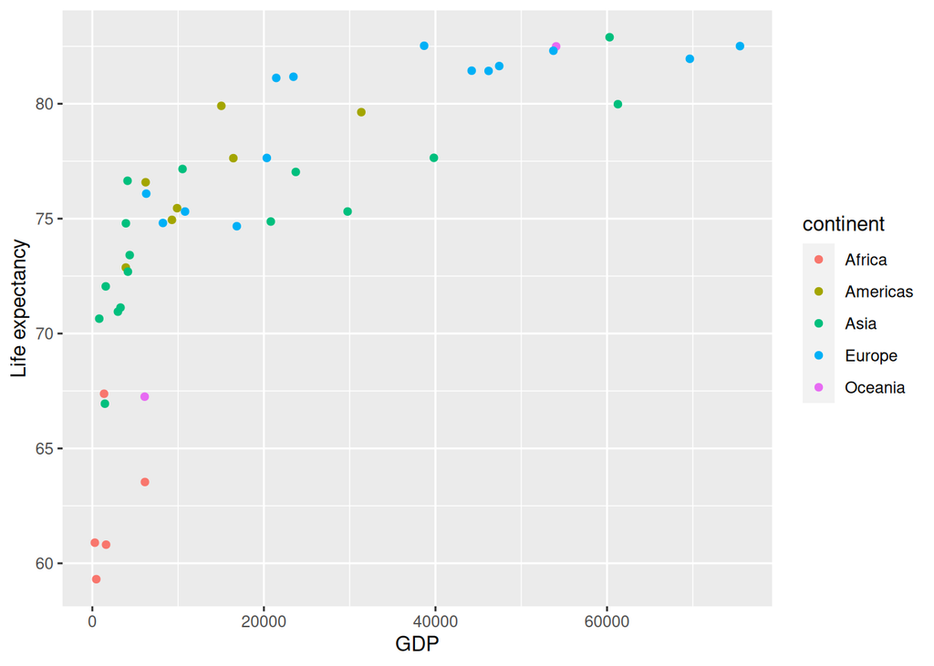

```r
# Your code here
sdg %>% filter(year == 2017) %>%
  ggplot(aes(gdp, life_expectancy, colour = continent)) +
  geom_point() +
  labs(x = "GDP", y = "Life expectancy")
```

### Task 13

In the code chunk below, write `R` code to display a scatter plot of `life_expectancy` (vertical) against the natural logarithm of `gdp` (horizontal) and also with a linear fit obtained by least squares!

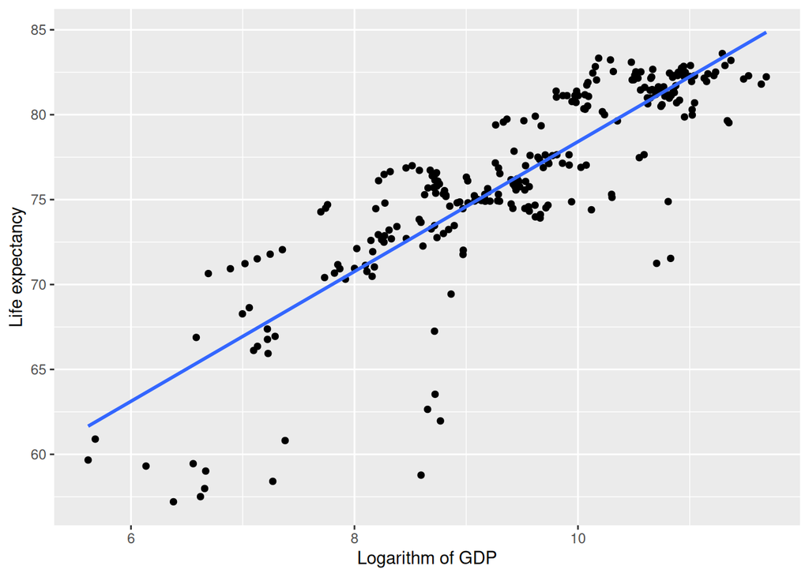

```r
# Your code here
sdg %>%
  ggplot(aes(log(gdp), life_expectancy)) +
  geom_point() +
  geom_smooth(method = "lm", se = FALSE) +
  labs(x = "Logarithm of GDP", y = "Life expectancy")
```

### Task 14

In the code chunk below, write `R` code to display a different scatter plot for each year of `life_expectancy`(vertical) against the natural logarithm of `gdp` (horizontal) and with a linear fit obtained by least squares!

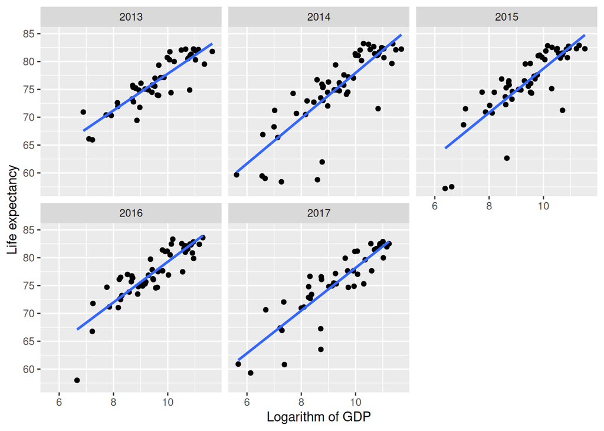

```r
# Your code here
sdg %>%
  ggplot(aes(log(gdp), life_expectancy)) +
  geom_point() +
  geom_smooth(method = "lm", se = FALSE) +
  facet_wrap(~year) +
  labs(x = "Logarithm of GDP", y = "Life expectancy")
```